# R-HW1

Margaret He

## Problem I

- (a): Names of the columns

```
## [1] "Steps"  "Miles"  "Floors" "Sleep"  "Day"    "Month"
```

- (b): Number of rows

```
## [1] 88
```

- (c): Results from using the summary function

```
##      Steps           Miles           Floors           Sleep        Day
##  Min.   :  114   Min.   :0.050   Min.   :  1.00   Min.   :0.000   F  :13
##  1st Qu.: 7722   1st Qu.:3.390   1st Qu.: 11.00   1st Qu.:7.383   M  :13
##  Median :10920   Median :4.930   Median : 16.00   Median :7.617   R  :12
##  Mean   :10749   Mean   :4.759   Mean   : 20.78   Mean   :7.407   Sat:13
##  3rd Qu.:13780   3rd Qu.:6.093   3rd Qu.: 27.00   3rd Qu.:8.104   Sun:13
##  Max.   :20122   Max.   :8.790   Max.   :140.00   Max.   :9.333   T  :12
##                                                                   W  :12
##    Month
##  Feb  :28
##  Jan  :31
##  March:29
##
##
##
##
```

This function shows the frequency of each category for categorical data and presents the statistical summary for numerical data.

- (d): Mean of the column “Steps”"

```
## [1] 10749.34
```

## Problem II

(Data for every day of the week)

- (a): Average steps

```
##   Day     Steps
## 1   F 13068.615
## 2   M 14500.846
## 3   R 10843.667
## 4 Sat  8222.538
## 5 Sun  6318.538
## 6   T 10501.583
## 7   W 11863.500
```

- (b): Average hours of sleep

```
##   Day    Sleep
## 1   F 7.591026
## 2   M 6.341026
## 3   R 7.412500
## 4 Sat 7.850000
## 5 Sun 7.238462
## 6   T 8.019444
## 7   W 7.444444
```

- (c): Standard deviation of steps taken

```
##   Day    Steps
## 1   F 3365.953
## 2   M 5362.416
## 3   R 2105.690
## 4 Sat 3270.769
## 5 Sun 3424.365
## 6   T 2631.131
## 7   W 3441.038
```

- (d): Standard deviation of hours of sleep

```
##   Day     Sleep
## 1   F 0.9029431
## 2   M 2.1613890
## 3   R 1.4411717
## 4 Sat 0.7228096
## 5 Sun 2.2390721
## 6   T 0.7544090
## 7   W 0.4347490
```

## Problem III

- (a): Results from using the fivenum function

```
## [1] 0.050 3.390 4.930 6.105 8.790
```

The fivenum function returns the minimum, the first quartile, the median, the third quartile, and the maximum.

- (b): Results from using the function table

```
##
##   F   M   R Sat Sun   T   W
##  13  13  12  13  13  12  12
```

The table function returns a frequency table

- (c): Median number of hours of sleep for every month

```
##   Month    Sleep
## 1   Feb 7.591667
## 2   Jan 7.616667
## 3 March 7.600000
```

- (d): Median distance traveled for every month

```
##   Month Miles
## 1   Feb  5.51
## 2   Jan  5.09
## 3 March  3.73
```

## Problem IV

- (a): Boxplot of the total number of steps for every day of the week

It appears that Sundays involve less activity than the other days.

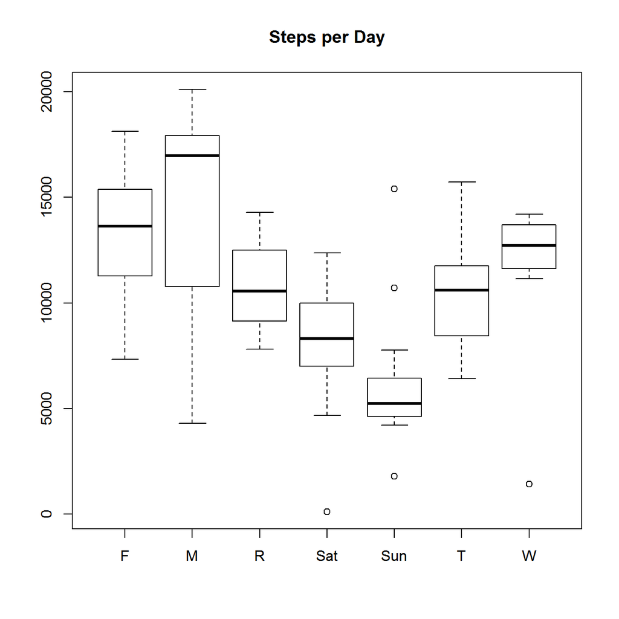

- (b): Boxplot of the total hours of sleep for every day of the week

It appears that Mondays are less restful than the other days.

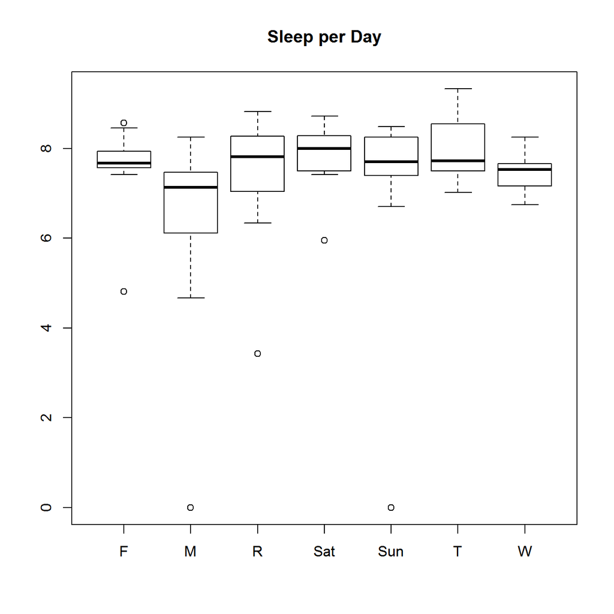

- (c): Based on the boxplot in part (a), there DOES appear to be outliers for Steps

```
## [1] TRUE
```

We have verified that the outliers occur on Wednesday, Saturday, and Sunday.

- (d): Based on the boxplot in part (b), there DOES appear to be outliers for Sleep

```
## [1] TRUE
```

We have verified that the outliers occur on Sunday, Monday, Thursday, Friday, and Saturday.

# Code Appendix

```
## Problem I
* (a): Names of the columns

names(ErinsFitbit)

* (b): Number of rows

nrow(ErinsFitbit)

* (c): Results from using the summary function

summary(ErinsFitbit)

This function shows the frequency of each category for categorical data and presents the statistical summary for numerical data.

* (d): Mean of the column "Steps""

mean(ErinsFitbit$Steps)

## Problem II
(Data for every day of the week)

* (a): Average steps

avg.steps = aggregate(Steps ~ Day,data = ErinsFitbit,mean)
avg.steps

* (b): Average hours of sleep

avg.sleep = aggregate(Sleep ~ Day,data = ErinsFitbit, mean)
avg.sleep

* (c): Standard deviation of steps taken

sd.steps = aggregate(Steps ~ Day, data = ErinsFitbit, sd)
sd.steps

* (d): Standard deviation of hours of sleep

sd.sleep = aggregate(Sleep ~ Day, data = ErinsFitbit, sd)
```

[output cut: 47 more lines]

```
lower.bound = Q3 - 1.5*(Q3-Q1)
upper.bound =  Q1 + 1.5*(Q3-Q1)
any(ErinsFitbit$Steps < lower.bound |ErinsFitbit$Steps > upper.bound)

We have verified that the outliers occur on Wednesday, Saturday, and Sunday.

* (d): Based on the boxplot in part (b), there DOES appear to be outliers for Sleep

Q1 = quantile(ErinsFitbit$Sleep,c(0.25))
Q3 = quantile(ErinsFitbit$Sleep,c(0.75))
lower.bound = Q1 - 1.5*(Q3-Q1)
upper.bound = Q3 + 1.5*(Q3-Q1)
any(ErinsFitbit$Sleep < lower.bound | ErinsFitbit$Sleep > upper.bound)

We have verified that the outliers occur on Sunday, Monday, Thursday, Friday, and Saturday.
```